# ST516 Homework 3

Sam Wozniak

March 23, 2018

```r
knitr::opts_chunk$set(echo = TRUE, error = TRUE)
library(Sleuth3)
library(ggplot2)
library(trtools)
library(COUNT)
library(npregfast)
library(DAAG)
library(tidyr)
options(digits = 4)
```

# Aflatoxicol and Liver Tumors in Trout

#### 1. Estimate a logistic regression model using dose as the explanatory variable. Report parameter estimes, standard errors, and CI’s. Write a brief summary that summarizes the effect of aflatoxiol using an odds ratio. Plot the model. Plot studentized residuals against predicted values. Comment on if you think the model is a good fit for the data

Summary: For a 0.1 ppm increase in Dose, the odds of a trout getting liver tumors increases by a factor of 4.19.

Comment: The model is not a good fit for the data. A majority of the studentized residuals are more extreme than 2 or -2.

```r
#logistic regression model
m <- glm(cbind(Tumor, Total - Tumor) ~ Dose, family = binomial, data = ex2116)
cbind(summary(m)$coefficients, confint(m))
```

```
##             Estimate Std. Error z value  Pr(>|z|)  2.5 %  97.5 %
## (Intercept)   -0.867    0.07673   -11.3 1.321e-29 -1.019 -0.7179
## Dose          14.334    0.93695    15.3 7.838e-53 12.558 16.2346
```

```r
#odds ratio
contrast(m, a = list(Dose = .2), b = list(Dose = .1), tf = exp)
```

```
##  estimate      se lower upper tvalue  df    pvalue
##     4.193 0.09369 3.489 5.038   15.3 Inf 7.838e-53
```

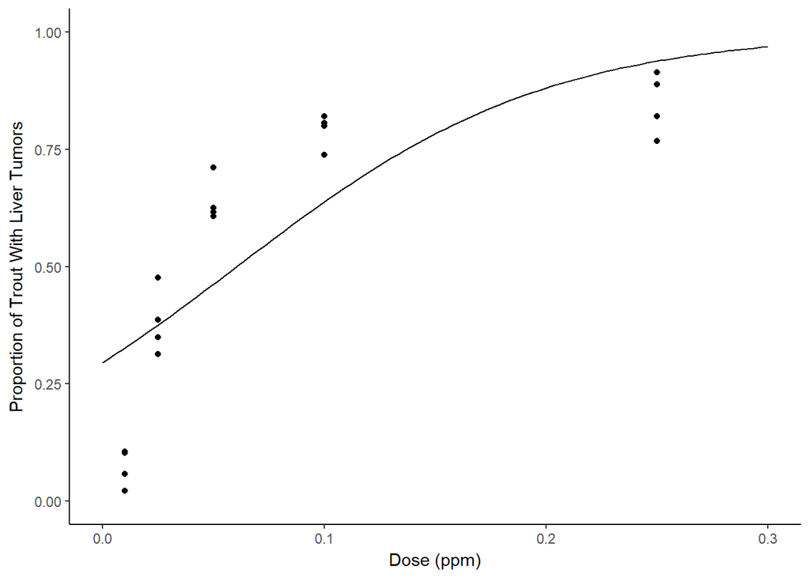

```r
#plot model
d <- expand.grid(Dose = seq(0, .3, length = 100))
d$yhat <- predict(m, newdata = d, type = "response")

p <- ggplot(ex2116, aes(x = Dose, y = Tumor/Total))
p <- p + geom_point() + theme_classic() + ylim(0,1)
p <- p + geom_line(aes(y = yhat), data = d)
p <- p + labs(x = "Dose (ppm)", y = "Proportion of Trout With Liver Tumors")
plot(p)
```

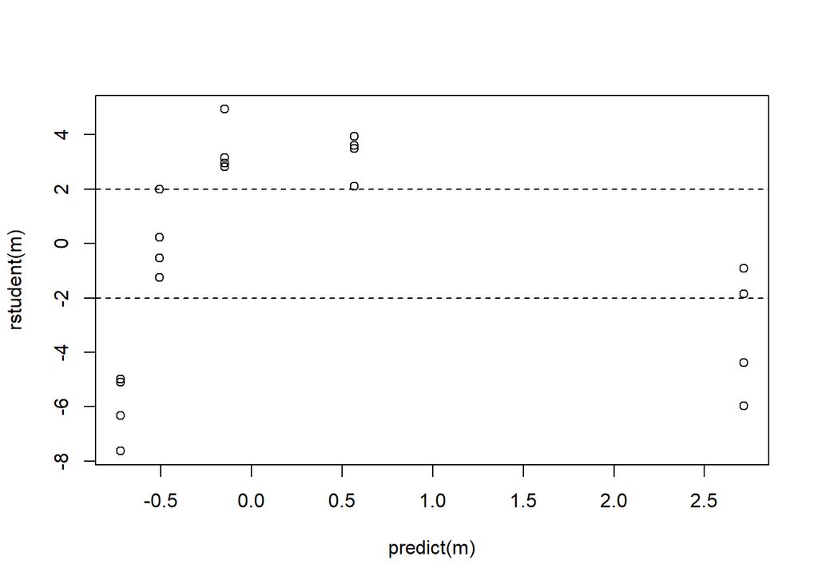

```r
#plot studentized residuals vs predicted
plot(predict(m), rstudent(m))
abline(-2, 0, lty = 2)
abline(2, 0, lty = 2)
```

#### 2. Repeat the previous problem except using the base-2 log of dose as the explanatory variable. Be sure your interpretation of the odds ratio accounts for the log transformation of dose.

Summary: For a doubling of dose, the odds of a trout getting liver tumors increases by a factor of 2.46.

Comment: This model is a better fit than the previous model, but still has a fair number of studentized residuals fall outside of (-2,2).

```r
#logistic regression model with log2 transformation of dose
m <- glm(cbind(Tumor, Total - Tumor) ~ log2(Dose), family = binomial, data = ex2116)
cbind(summary(m)$coefficients, confint(m))
```

```
##             Estimate Std. Error z value  Pr(>|z|)  2.5 % 97.5 %
## (Intercept)   4.1634     0.2085   19.97 9.564e-89 3.7631  4.581
## log2(Dose)    0.8997     0.0446   20.17 1.628e-90 0.8141  0.989
```

```r
#odds ratio
contrast(m, a = list(Dose = .2), b = list(Dose = .1), tf = exp)
```

```
##  estimate     se lower upper tvalue  df    pvalue
##     2.459 0.0446 2.253 2.684  20.17 Inf 1.628e-90
```

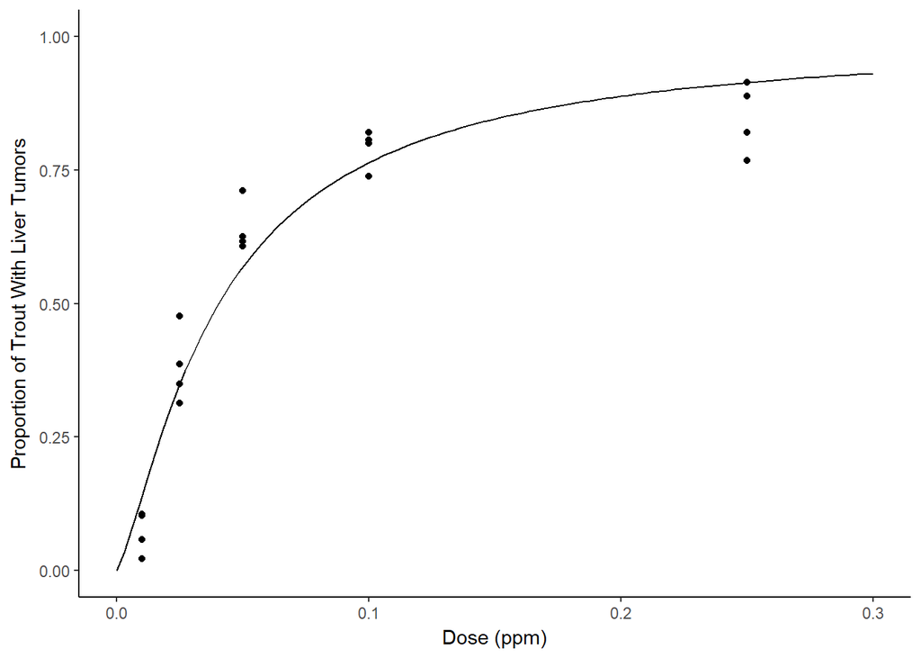

```r
#plot model
d <- expand.grid(Dose = seq(0, .3, length = 100))
d$yhat <- predict(m, newdata = d, type = "response")

p <- ggplot(ex2116, aes(x = Dose, y = Tumor/Total))
p <- p + geom_point() + theme_classic() + ylim(0,1)
p <- p + geom_line(aes(y = yhat), data = d)
p <- p + labs(x = "Dose (ppm)", y = "Proportion of Trout With Liver Tumors")
plot(p)
```

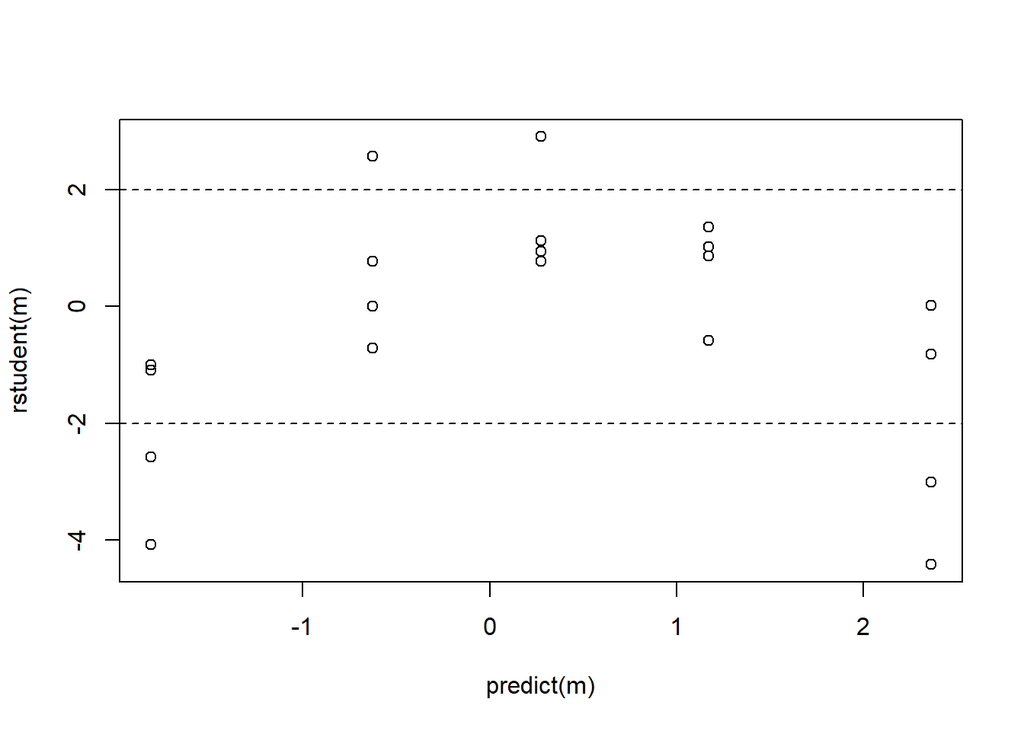

```r
#plot studentized residuals vs predicted
plot(predict(m), rstudent(m))
abline(-2, 0, lty = 2)
abline(2, 0, lty = 2)
```

#### 3. Repeat the previous two problems, but specify dose as a factor.

Summary:

For an increase in Dose from 0.01 to 0.025 ppm, the odds of a trout getting liver tumors increases by a factor of 7.95.

For an increase in Dose from 0.01 to 0.1 ppm, the odds of a trout getting liver tumors increases by a factor of 48.91.

For an increase in Dose from 0.01 to 0.25 ppm, the odds of a trout getting liver tumors increases by a factor of 70.84.

Comment: The studentized residuals for this model look much better than either of the previous two models–there are few studentized residuals that fall outside (-2,2), and those that do, are not very from from -2 or 2.

```r
#logistic regression model
m <- glm(cbind(Tumor, Total - Tumor) ~ factor(Dose), family = binomial, data = ex2116)
cbind(summary(m)$coefficients, confint(m))
```

```
##                   Estimate Std. Error z value  Pr(>|z|)  2.5 % 97.5 %
## (Intercept)         -2.556     0.2076 -12.310 8.049e-35 -2.988 -2.171
## factor(Dose)0.025    2.073     0.2353   8.809 1.264e-18  1.628  2.553
## factor(Dose)0.05     3.132     0.2354  13.306 2.130e-40  2.688  3.614
## factor(Dose)0.1      3.890     0.2453  15.857 1.252e-56  3.427  4.391
## factor(Dose)0.25     4.260     0.2566  16.605 6.436e-62  3.775  4.784
```

```r
#odds ratio
contrast(m, a = list(Dose = c('0.025', '0.05', '0.1', '0.25')),
         b = list(Dose = '0.01'),
         cnames = c("0.025 vs 0.01", "0.05 vs 0.01", "0.1 vs 0.01", "0.25 vs 0.01"), tf = exp)
```

```
##               estimate     se lower  upper tvalue  df    pvalue
## 0.025 vs 0.01    7.945 0.2353  5.01  12.60  8.809 Inf 1.264e-18
## 0.05 vs 0.01    22.920 0.2354 14.45  36.36 13.306 Inf 2.130e-40
## 0.1 vs 0.01     48.909 0.2453 30.24  79.10 15.857 Inf 1.252e-56
## 0.25 vs 0.01    70.840 0.2566 42.84 117.13 16.605 Inf 6.436e-62
```

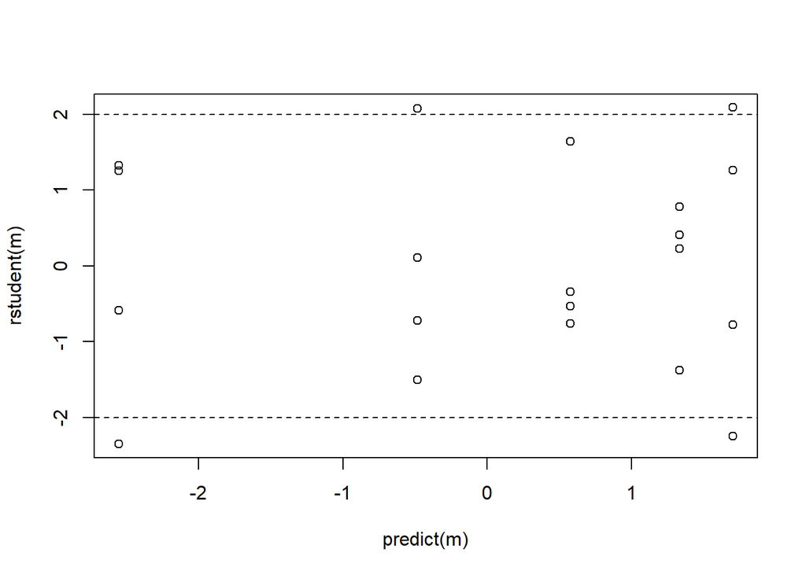

```r
#plot studentized residuals vs predicted
plot(predict(m), rstudent(m))
abline(-2, 0, lty = 2)
abline(2, 0, lty = 2)
```

# Effects of Commercial Fishing on Abundance

#### 1. Estimate a Poisson regression model where expected number of fish depends on trawl depth and period. Include an interaction. Account for the response vairable being a rate (# of fish per unit area) and that trawls vary in terms of their area. Report parameter estimates, se’s, and CI’s for model parameters.

```r
data(fishing)
m <- glm(totabund ~ offset(log(sweptarea)) + meandepth * period,
         family = poisson, data = fishing)
cbind(summary(m)$coefficients, confint(m))
```

```
##                             Estimate Std. Error  z value   Pr(>|z|)
## (Intercept)               -3.4228194  1.490e-02 -229.672  0.000e+00
## meandepth                 -0.0009713  7.965e-06 -121.945  0.000e+00
## period2000-2002           -0.7711169  2.973e-02  -25.937 2.547e-148
## meandepth:period2000-2002  0.0001318  1.524e-05    8.651  5.090e-18
##                                2.5 %     97.5 %
## (Intercept)               -3.4520234 -3.3936038
## meandepth                 -0.0009869 -0.0009557
## period2000-2002           -0.8293945 -0.7128522
## meandepth:period2000-2002  0.0001019  0.0001616
```

#### 2. Plot.

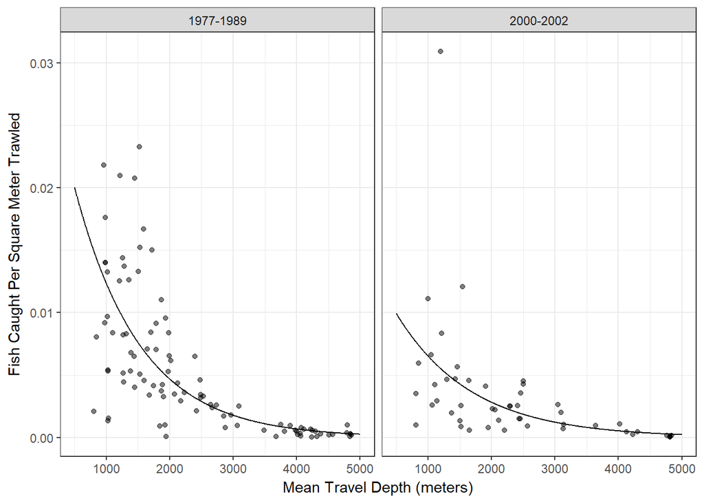

```r
d <- expand.grid(period = levels(fishing$period),
                 meandepth = seq(500, 5000, length = 1000), sweptarea = 1)
d$yhat <- predict(m, newdata = d, type = "response")

p <- ggplot(fishing, aes(x = meandepth, y = totabund/sweptarea))
p <- p + geom_point(alpha = 0.5) + facet_wrap(~period) + theme_bw()
p <- p + geom_line(aes(y = yhat, group = period), data = d)
p <- p + labs(x = "Mean Travel Depth (meters)",
              y = "Fish Caught Per Square Meter Trawled")
plot(p)
```

#### 3. Write out regression model implied by results of summary

E(Yi) = exp(b<sub>0</sub>* + b<sub>1</sub>d<sub>i</sub> + b<sub>2</sub>p<sub>i</sub> + b<sub>3</sub>d<sub>i</sub>p<sub>i</sub>)

where

b<sub>0</sub>* = log(S) + b<sub>0</sub> = log(sweptarea) + b<sub>0</sub>

d<sub>i</sub> = meandepth

p<sub>i</sub> =

- 1 if period = 2000-2002
- 0 if period = 1977-1989

Casewise:

E(Y<sub>i</sub>) = exp(b<sub>0</sub> + b<sub>1</sub>d<sub>i</sub>), for the period 1977-1989

E(Y<sub>i</sub>) = exp(b<sub>0</sub> + b<sub>2</sub> + (b<sub>1</sub> + b<sub>3</sub>) * d<sub>i</sub>), for the period 2000-2002

#### 4. Using contrast briefly explain (a) how the estimated fish per area changes with mean depth for each period, and (b) how the estimated fish per area changed between the two periods at mean depths of 1000, 2000, 3000, 4000, 5000 meters.

Interpretation:

1. In the period 1977-1989, for a 1000 m increase in mean depth, the estimated fish per area changes by a factor of 0.37.

In the period 2000-2002, for a 1000 m increase in mean depth, the estimated fish per area changes by a factor of 0.43.

2. From the period 1977-1989 to the period 2000-2002, the estimated fish per area changes by a factor of 0.52 at a depth of 1000 m.

From the period 1977-1989 to the period 2000-2002, the estimated fish per area changes by a factor of 0.60 at a depth of 2000 m.

From the period 1977-1989 to the period 2000-2002, the estimated fish per area changes by a factor of 0.69 at a depth of 3000 m.

From the period 1977-1989 to the period 2000-2002, the estimated fish per area changes by a factor of 0.78 at a depth of 4000 m.

From the period 1977-1989 to the period 2000-2002, the estimated fish per area changes by a factor of 0.89 at a depth of 5000 m.

```r
#a)
contrast(m, a = list(period = "1977-1989", meandepth = 2000, sweptarea = 1),
         b = list(period = "1977-1989", meandepth = 1000, sweptarea = 1),
         cname = "1977-1989", tf = exp)
```

```
##           estimate       se  lower  upper tvalue  df pvalue
## 1977-1989   0.3786 0.007965 0.3727 0.3846 -121.9 Inf      0
```

```r
contrast(m, a = list(period = "2000-2002", meandepth = 2000, sweptarea = 1),
         b = list(period = "2000-2002", meandepth = 1000, sweptarea = 1),
         cname = "2000-2002", tf = exp)
```

```
##           estimate      se  lower  upper tvalue  df pvalue
## 2000-2002    0.432 0.01299 0.4211 0.4431 -64.61 Inf      0
```

```r
#b)
contrast(m, a = list(period = "2000-2002", meandepth = c(1000, 2000, 3000, 4000, 5000), sweptarea = 1),
         b = list(period = "1977-1989", meandepth = c(1000, 2000, 3000, 4000, 5000), sweptarea = 1),
         cname = c('1000 m', '2000 m', '3000 m', '4000 m', '5000 m'), tf = exp)
```

```
##        estimate      se  lower  upper  tvalue  df     pvalue
## 1000 m   0.5277 0.01740 0.5100 0.5460 -36.740 Inf 1.700e-295
## 2000 m   0.6020 0.01364 0.5861 0.6183 -37.199 Inf 7.157e-303
## 3000 m   0.6869 0.02311 0.6565 0.7187 -16.256 Inf  2.011e-59
## 4000 m   0.7837 0.03669 0.7293 0.8421  -6.644 Inf  3.045e-11
## 5000 m   0.8941 0.05121 0.8087 0.9885  -2.186 Inf  2.883e-02
```